# MTH 562 Project 2

Mark May and Andrew Walther

3/21/2019

```r
#install.packages("binom")
library(mosaic)
library(RColorBrewer)
library(binom)
cols <- brewer.pal(8, 'Set1')
```

## Introduction

We will analyze the Wald, Wilson, and Agresti-Coull confidence intervals based off of their interval lengths and coverage levels. This will be done with random samples from a binomial distribution with a selection of six different sets of parameters.

# Wald Confidence Interval

## $p = 0.5, n = 20$

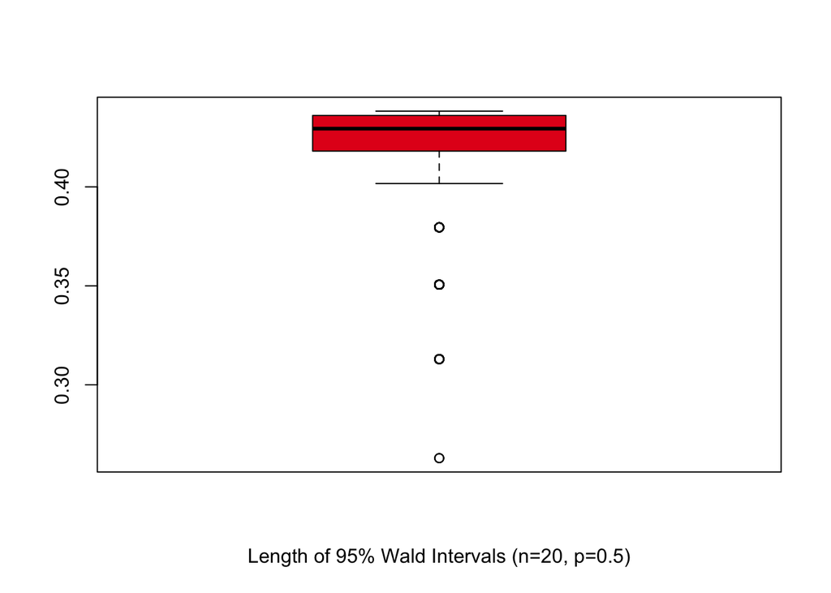

```r
set.seed(562)
p11 <- 0.5
n11 <- 20

wald_lower1 <- c()
wald_upper1 <- c()

for(i in 1:10000){
X_11 <- rbinom(prob=p11, size=n11, n=1)
intervals11 <- binom.confint(x=X_11, n=n11, conf.level=0.95, method='asymptotic')

wald_lower1[i] <- intervals11[1, 5]
wald_upper1[i] <- intervals11[1, 6]
}

coverage_wald1 <- sum(wald_lower1 <= p11 & wald_upper1 >=p11)/10000

length_wald1 <- wald_upper1 - wald_lower1

boxplot(length_wald1, col=cols[1], xlab='Length of 95% Wald Intervals (n=20, p=0.5)')
```

```r
coverage_wald1
```

```
## [1] 0.9616
```

```r
coverage_wald_diff95_1 <- coverage_wald1 - 0.95
coverage_wald_diff95_1
```

```
## [1] 0.0116
```

```r
mean(length_wald1)
```

```
## [1] 0.4267852
```

- The Wald confidence interval with $p = 0.5, n = 20$ has a length of $0.4268$ and coverage level of $0.9616$. This exceeds the desired $95%$ confidence level by $0.0116$.

## $p = 0.5, n = 50$

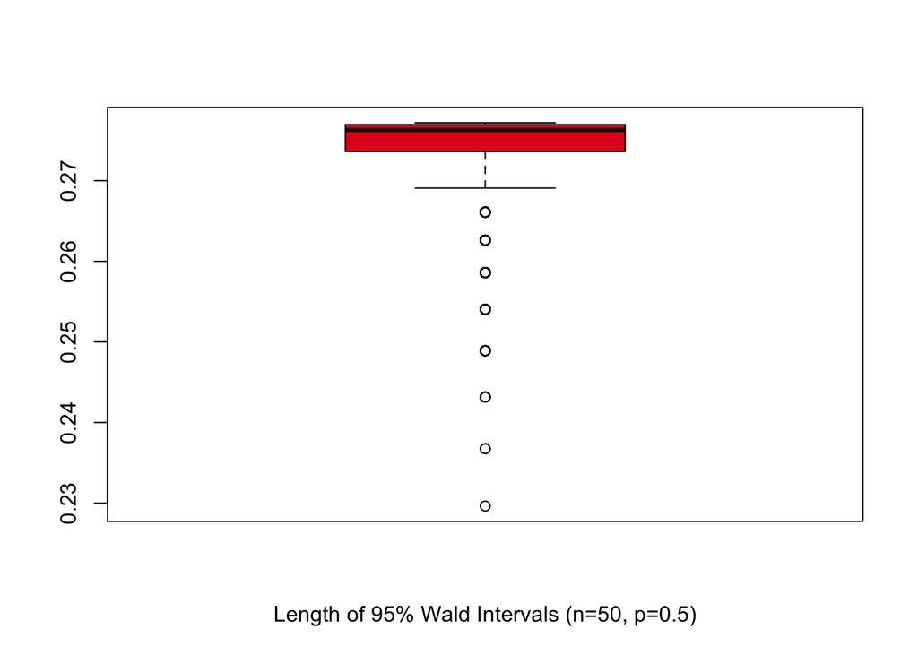

```r
set.seed(562)
p12 <- 0.5
n12 <- 50

wald_lower2 <- c()
wald_upper2 <- c()

for(i in 1:10000){
X_12 <- rbinom(prob=p12, size=n12, n=1)
intervals12 <- binom.confint(x=X_12, n=n12, conf.level=0.95, method='asymptotic')

wald_lower2[i] <- intervals12[1, 5]
wald_upper2[i] <- intervals12[1, 6]
}

coverage_wald2 <- sum(wald_lower2 <= p12 & wald_upper2 >=p12)/10000

length_wald2 <- wald_upper2 - wald_lower2
boxplot(length_wald2, col=cols[1], xlab='Length of 95% Wald Intervals (n=50, p=0.5)')
```

```r
coverage_wald2
```

```
## [1] 0.9359
```

```r
coverage_wald_diff95_2 <- coverage_wald2 - 0.95
coverage_wald_diff95_2
```

```
## [1] -0.0141
```

```r
mean(length_wald2)
```

```
## [1] 0.2743491
```

- The Wald confidence interval with $p = 0.5, n = 50$ has a length of $0.2743$ and coverage level of $0.9359$. This falls short of the desired $95%$ confidence level by $0.0141$.

## $p = 0.7, n = 20$

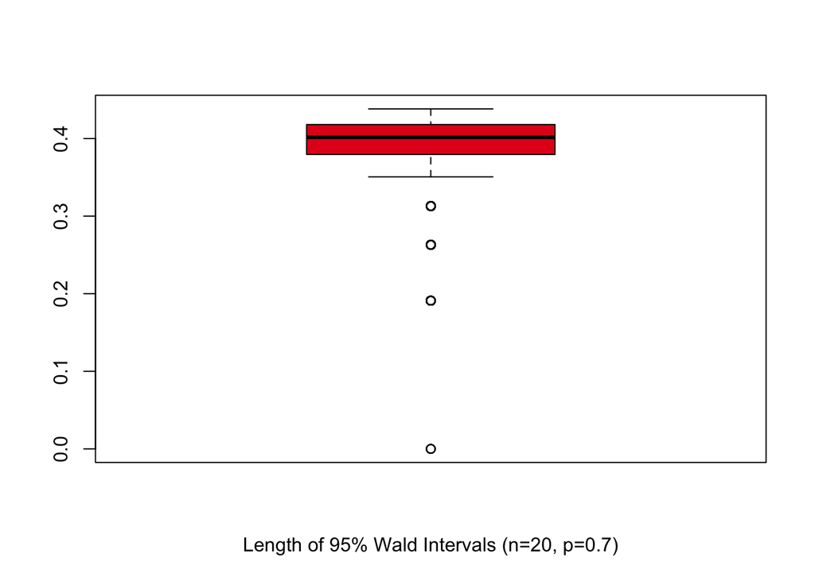

```r
set.seed(562)
p13 <- 0.7
n13 <- 20

wald_lower3 <- c()
wald_upper3 <- c()

for(i in 1:10000){
X_13 <- rbinom(prob=p13, size=n13, n=1)
intervals13 <- binom.confint(x=X_13, n=n13, conf.level=0.95, method='asymptotic')

wald_lower3[i] <- intervals13[1, 5]
wald_upper3[i] <- intervals13[1, 6]
}

coverage_wald3 <- sum(wald_lower3 <= p13 & wald_upper3 >=p13)/10000

length_wald3 <- wald_upper3 - wald_lower3
boxplot(length_wald3, col=cols[1], xlab='Length of 95% Wald Intervals (n=20, p=0.7)')
```

```r
coverage_wald3
```

```
## [1] 0.9488
```

```r
coverage_wald_diff95_3<- coverage_wald3 - 0.95
coverage_wald_diff95_3
```

```
## [1] -0.0012
```

```r
mean(length_wald3)
```

```
## [1] 0.388804
```

- The Wald confidence interval with $p = 0.7, n = 20$ has a length of $0.3888$ and coverage level of $0.9488$. This falls short the desired $95%$ confidence level by $0.0012$.

## $p = 0.7, n = 50$

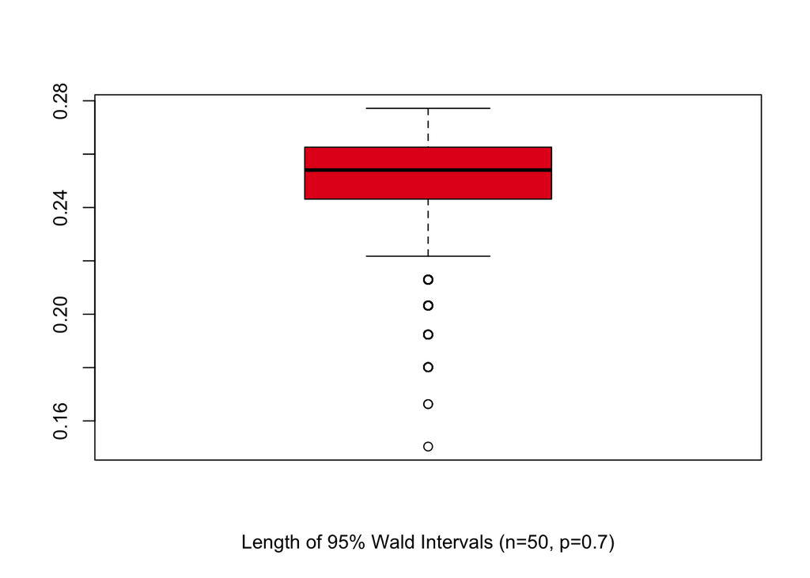

```r
set.seed(562)
p14 <- 0.7
n14 <- 50

wald_lower4 <- c()
wald_upper4 <- c()

for(i in 1:10000){
X_14 <- rbinom(prob=p14, size=n14, n=1)
intervals14 <- binom.confint(x=X_14, n=n14, conf.level=0.95, method='asymptotic')

wald_lower4[i] <- intervals14[1, 5]
wald_upper4[i] <- intervals14[1, 6]
}

coverage_wald4 <- sum(wald_lower4 <= p14 & wald_upper4 >=p14)/10000

length_wald4 <- wald_upper4 - wald_lower4
boxplot(length_wald4, col=cols[1], xlab='Length of 95% Wald Intervals (n=50, p=0.7)')
```

```r
coverage_wald4
```

```
## [1] 0.9364
```

```r
coverage_wald_diff95_4 <- coverage_wald4 - 0.95
coverage_wald_diff95_4
```

```
## [1] -0.0136
```

```r
mean(length_wald4)
```

```
## [1] 0.2509392
```

- The Wald confidence interval with $p = 0.7, n = 50$ has a length of $0.2509$ and coverage level of $0.9364$. This falls short the desired $95%$ confidence level by $0.0136$.

## $p = 0.9, n = 20$

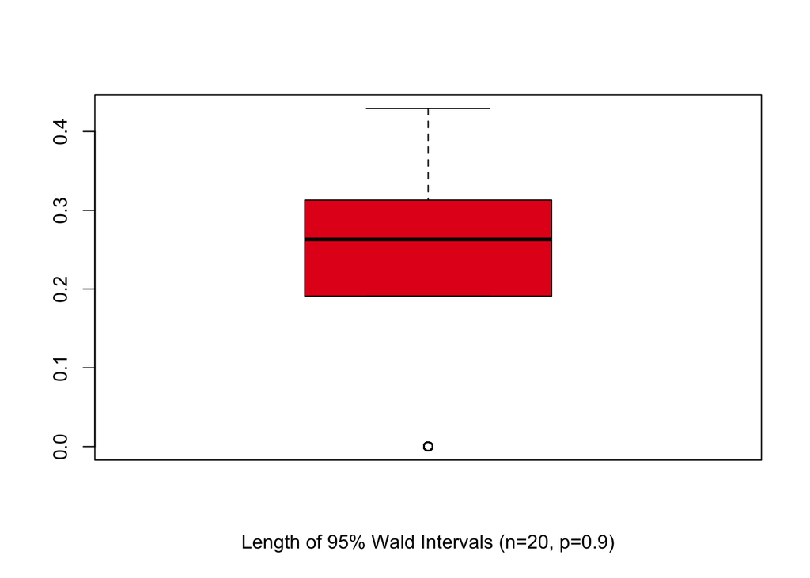

```r
set.seed(562)
p15 <- 0.9
n15 <- 20

wald_lower5 <- c()
wald_upper5 <- c()

for(i in 1:10000){
X_15 <- rbinom(prob=p15, size=n15, n=1)
intervals15 <- binom.confint(x=X_15, n=n15, conf.level=0.95, method='asymptotic')

wald_lower5[i] <- intervals15[1, 5]
wald_upper5[i] <- intervals15[1, 6]
}

coverage_wald5 <- sum(wald_lower5 <= p15 & wald_upper5 >=p15)/10000

length_wald5 <- wald_upper5 - wald_lower5
boxplot(length_wald5, col=cols[1], xlab='Length of 95% Wald Intervals (n=20, p=0.9)')
```

```r
coverage_wald5
```

```
## [1] 0.8744
```

```r
coverage_wald_diff95_5 <- coverage_wald5 - 0.95
coverage_wald_diff95_5
```

```
## [1] -0.0756
```

```r
mean(length_wald5)
```

```
## [1] 0.2337099
```

- The Wald confidence interval with $p = 0.9, n = 20$ has a length of $0.2337$ and coverage level of $0.8744$. This falls short the desired $95%$ confidence level by $0.0756$.

## $p = 0.9, n = 50$

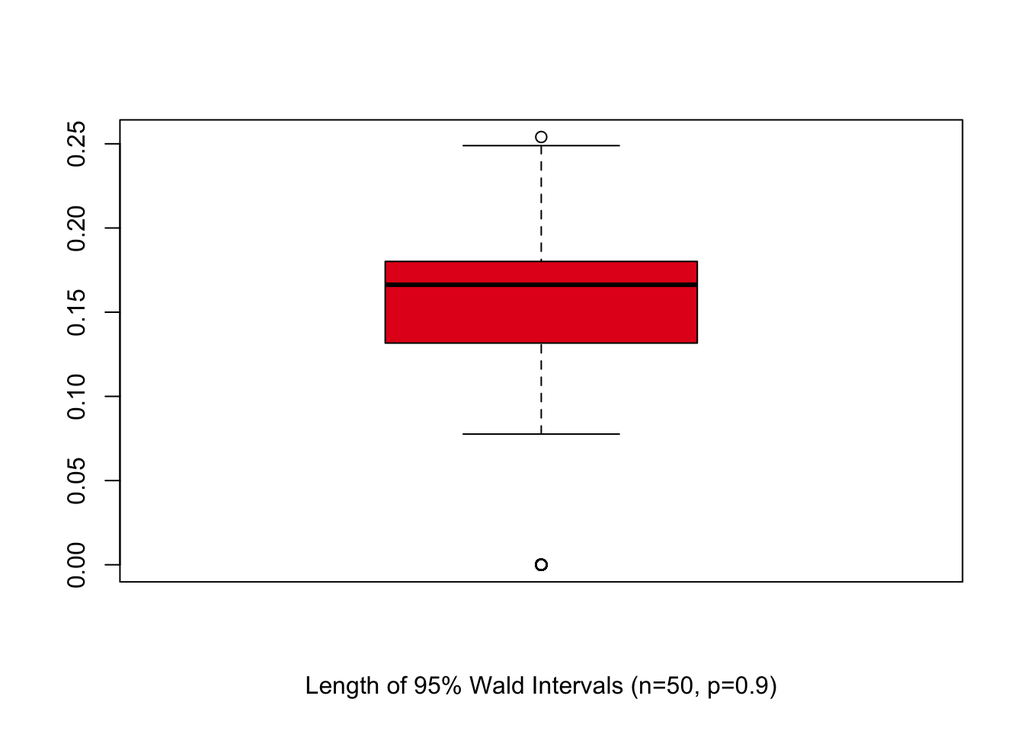

```r
set.seed(562)
p16 <- 0.9
n16 <- 50

wald_lower6 <- c()
wald_upper6 <- c()

for(i in 1:10000){
X_16 <- rbinom(prob=p16, size=n16, n=1)
intervals16 <- binom.confint(x=X_16, n=n16, conf.level=0.95, method='asymptotic')

wald_lower6[i] <- intervals16[1, 5]
wald_upper6[i] <- intervals16[1, 6]
}

coverage_wald6 <- sum(wald_lower6 <= p16 & wald_upper6 >=p16)/10000

length_wald6 <- wald_upper6 - wald_lower6
boxplot(length_wald6, col=cols[1], xlab='Length of 95% Wald Intervals (n=50, p=0.9)')
```

```r
coverage_wald6
```

```
## [1] 0.8771
```

```r
coverage_wald_diff95_6 <- coverage_wald6 - 0.95
coverage_wald_diff95_6
```

```
## [1] -0.0729
```

```r
mean(length_wald6)
```

```
## [1] 0.1611018
```

- The Wald confidence interval with $p = 0.9, n = 50$ has a length of $0.1611$ and coverage level of $0.8771$. This falls short the desired $95%$ confidence level by $0.0729$.

# Wilson Confidence Interval

## $p = 0.5, n = 20$

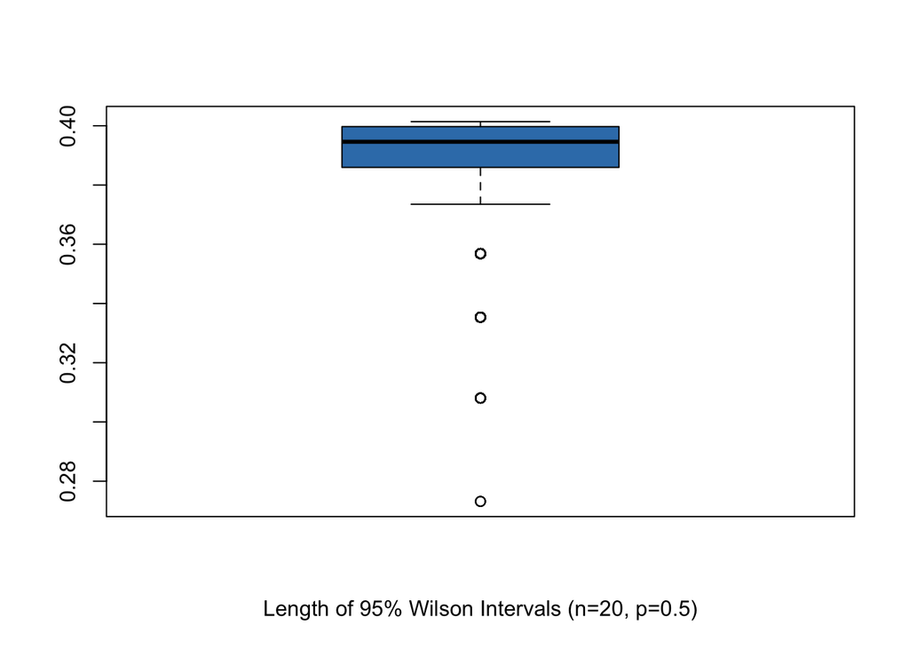

```r
set.seed(562)
p21 <- 0.5
n21 <- 20

wilson_lower1 <- c()
wilson_upper1 <- c()

for(i in 1:10000){
X_21 <- rbinom(prob=p21, size=n21, n=1)
intervals21 <- binom.confint(x=X_21, n=n21, conf.level=0.95, method='wilson')

wilson_lower1[i] <- intervals21[1, 5]
wilson_upper1[i] <- intervals21[1, 6]
}

coverage_wilson1 <- sum(wilson_lower1 <= p21 & wald_upper1 >=p21)/10000

length_wilson1 <- wilson_upper1 - wilson_lower1
boxplot(length_wilson1, col=cols[2], xlab='Length of 95% Wilson Intervals (n=20, p=0.5)')
```

```r
coverage_wilson1
```

```
## [1] 0.9616
```

```r
coverage_wilson_diff95_1 <- coverage_wilson1 - 0.95
coverage_wilson_diff95_1
```

```
## [1] 0.0116
```

```r
mean(length_wilson1)
```

```
## [1] 0.3926499
```

- The Wilson confidence interval with $p = 0.5, n = 20$ has a length of $0.3926$ and coverage level of $0.9616$. This exceeds the desired $95%$ confidence level by $0.0116$.

## $p = 0.5, n = 50$

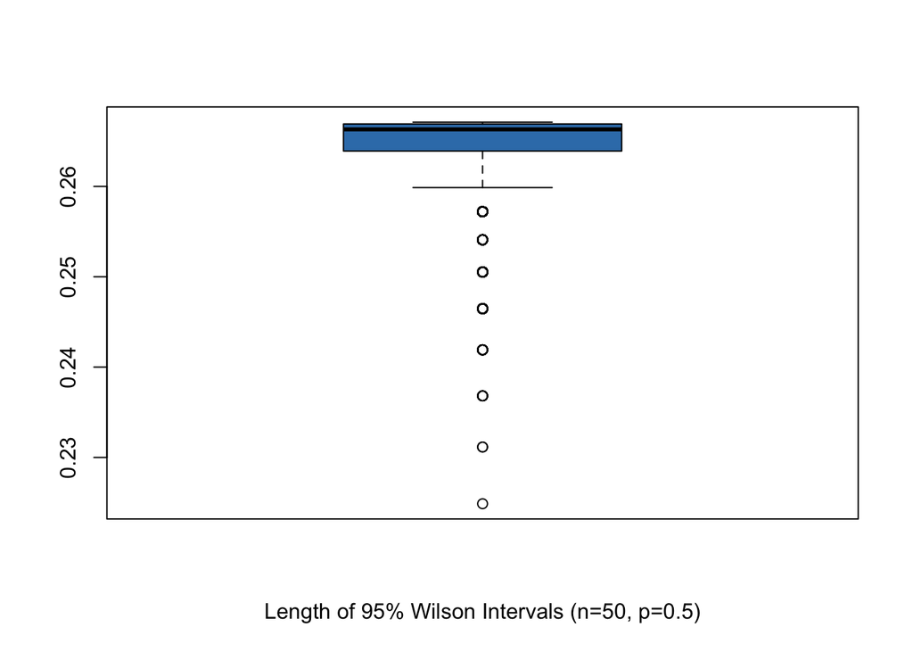

```r
set.seed(562)
p22 <- 0.5
n22 <- 50

wilson_lower2 <- c()
wilson_upper2 <- c()

for(i in 1:10000){
X_22 <- rbinom(prob=p22, size=n22, n=1)
intervals22 <- binom.confint(x=X_22, n=n22, conf.level=0.95, method='wilson')

wilson_lower2[i] <- intervals22[1, 5]
wilson_upper2[i] <- intervals22[1, 6]
}

coverage_wilson2 <- sum(wilson_lower2 <= p22 & wilson_upper2 >=p22)/10000

length_wilson2 <- wilson_upper2 - wilson_lower2
boxplot(length_wilson2, col=cols[2], xlab='Length of 95% Wilson Intervals (n=50, p=0.5)')
```

```r
coverage_wilson2
```

```
## [1] 0.9359
```

```r
coverage_wilson_diff95_2 <- coverage_wilson2 - 0.95
coverage_wilson_diff95_2
```

```
## [1] -0.0141
```

```r
mean(length_wilson2)
```

```
## [1] 0.2645785
```

- The Wilson confidence interval with $p = 0.5, n = 50$ has a length of $0.2646$ and coverage level of $0.9359$. This falls short of the desired $95%$ confidence level by $0.0141$.

## $p = 0.7, n = 20$

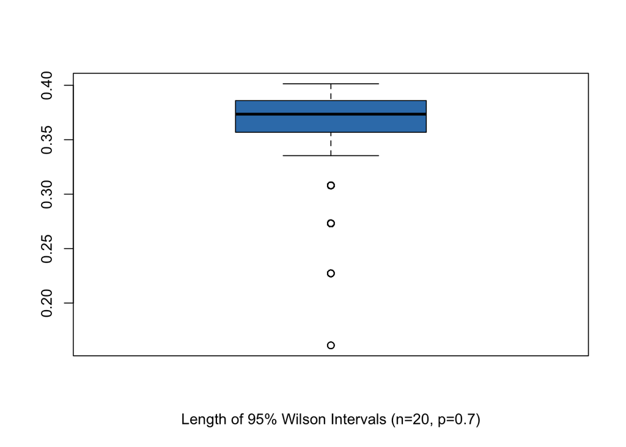

```r
set.seed(562)
p23 <- 0.7
n23 <- 20

wilson_lower3 <- c()
wilson_upper3 <- c()

for(i in 1:10000){
X_23 <- rbinom(prob=p23, size=n23, n=1)
intervals23 <- binom.confint(x=X_23, n=n23, conf.level=0.95, method='wilson')

wilson_lower3[i] <- intervals23[1, 5]
wilson_upper3[i] <- intervals23[1, 6]
}

coverage_wilson3 <- sum(wilson_lower3 <= p23 & wilson_upper3 >=p23)/10000

length_wilson3 <- wilson_upper3 - wilson_lower3
boxplot(length_wilson3, col=cols[2], xlab='Length of 95% Wilson Intervals (n=20, p=0.7)')
```

```r
coverage_wilson3
```

```
## [1] 0.9769
```

```r
coverage_wilson_diff95_3 <- coverage_wilson3 - 0.95
coverage_wilson_diff95_3
```

```
## [1] 0.0269
```

```r
mean(length_wilson3)
```

```
## [1] 0.3642652
```

- The Wilson confidence interval with $p = 0.7, n = 20$ has a length of $0.3643$ and coverage level of $0.9769$. This exceeds the desired $95%$ confidence level by $0.0269$.

## $p = 0.7, n = 50$

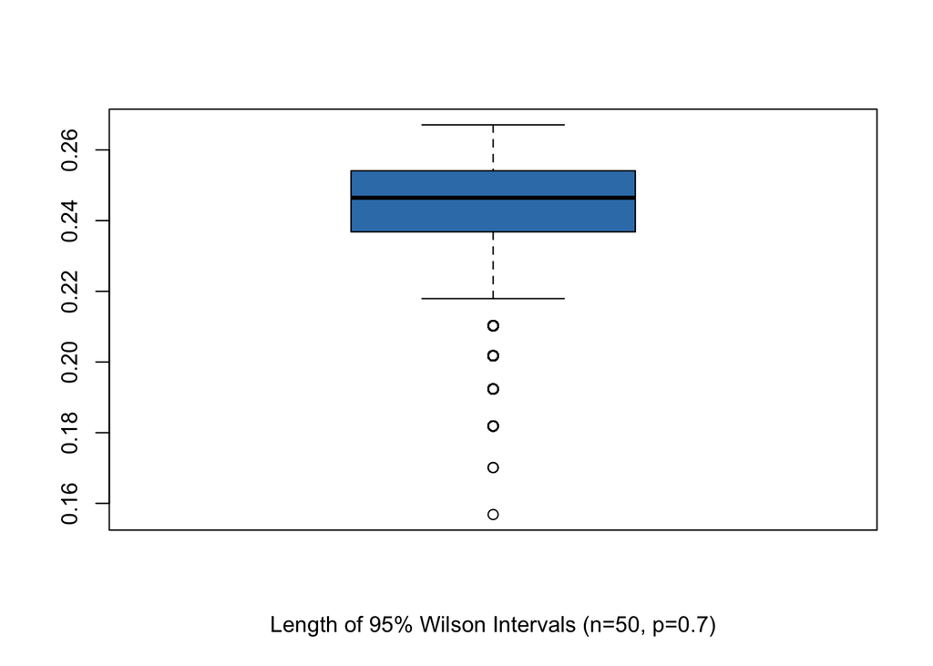

```r
set.seed(562)
p24 <- 0.7
n24 <- 50

wilson_lower4 <- c()
wilson_upper4 <- c()

for(i in 1:10000){
X_24 <- rbinom(prob=p24, size=n24, n=1)
intervals24 <- binom.confint(x=X_24, n=n24, conf.level=0.95, method='wilson')

wilson_lower4[i] <- intervals24[1, 5]
wilson_upper4[i] <- intervals24[1, 6]
}

coverage_wilson4 <- sum(wilson_lower4 <= p24 & wilson_upper4 >=p24)/10000

length_wilson4 <- wilson_upper4 - wilson_lower4
boxplot(length_wilson4, col=cols[2], xlab='Length of 95% Wilson Intervals (n=50, p=0.7)')
```

```r
coverage_wilson4
```

```
## [1] 0.9587
```

```r
coverage_wilson_diff95_4 <- coverage_wilson4 - 0.95
coverage_wilson_diff95_4
```

```
## [1] 0.0087
```

```r
mean(length_wilson4)
```

```
## [1] 0.2437565
```

- The Wilson confidence interval with $p = 0.7, n = 50$ has a length of $0.2438$ and coverage level of $0.9587$. This exceeds the desired $95%$ confidence level by $0.0087$.

## $p = 0.9, n = 20$

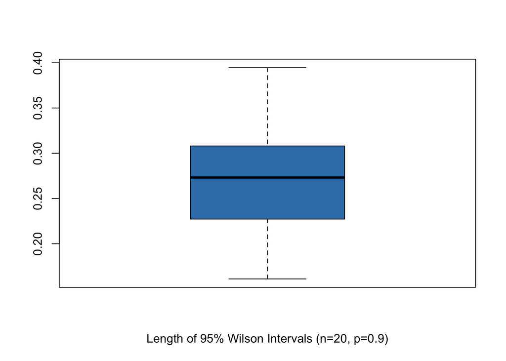

```r
set.seed(562)
p25 <- 0.9
n25 <- 20

wilson_lower5 <- c()
wilson_upper5 <- c()

for(i in 1:10000){
X_25 <- rbinom(prob=p25, size=n25, n=1)
intervals25 <- binom.confint(x=X_25, n=n25, conf.level=0.95, method='wilson')

wilson_lower5[i] <- intervals25[1, 5]
wilson_upper5[i] <- intervals25[1, 6]
}

coverage_wilson5 <- sum(wilson_lower5 <= p25 & wilson_upper5 >=p25)/10000

length_wilson5 <- wilson_upper5 - wilson_lower5
boxplot(length_wilson5, col=cols[2], xlab='Length of 95% Wilson Intervals (n=20, p=0.9)')
```

```r
coverage_wilson5
```

```
## [1] 0.9553
```

```r
coverage_wilson_diff95_5 <- coverage_wilson5 - 0.95
coverage_wilson_diff95_5
```

```
## [1] 0.0053
```

```r
mean(length_wilson5)
```

```
## [1] 0.2629281
```

## $p = 0.9, n = 50$

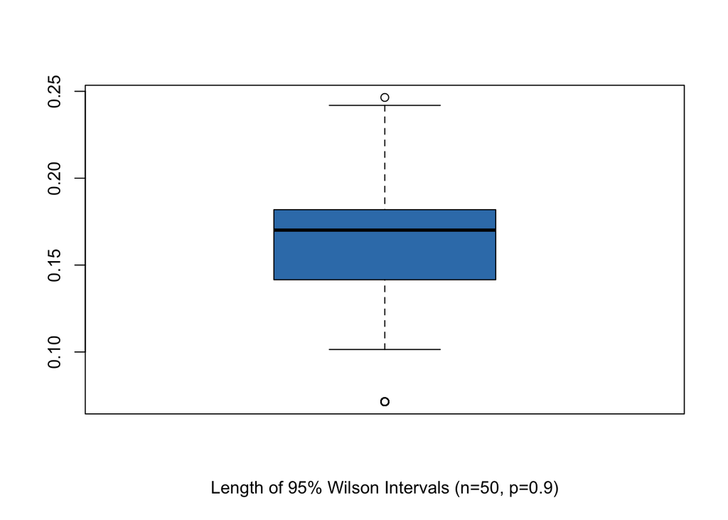

```r
set.seed(562)
p26 <- 0.9
n26 <- 50

wilson_lower6 <- c()
wilson_upper6 <- c()

for(i in 1:10000){
X_26 <- rbinom(prob=p26, size=n26, n=1)
intervals26 <- binom.confint(x=X_26, n=n26, conf.level=0.95, method='wilson')

wilson_lower6[i] <- intervals26[1, 5]
wilson_upper6[i] <- intervals26[1, 6]
}

coverage_wilson6 <- sum(wilson_lower6 <= p26 & wilson_upper6 >=p26)/10000

length_wilson6 <- wilson_upper6 - wilson_lower6
boxplot(length_wilson6, col=cols[2], xlab='Length of 95% Wilson Intervals (n=50, p=0.9)')
```

```r
coverage_wilson6
```

```
## [1] 0.9713
```

```r
coverage_wilson_diff95_6 <- coverage_wilson6 - 0.95
coverage_wilson_diff95_6
```

```
## [1] 0.0213
```

```r
mean(length_wilson6)
```

```
## [1] 0.1665023
```

# Agresti-Coull Confidence Interval

## $p = 0.5, n = 20$

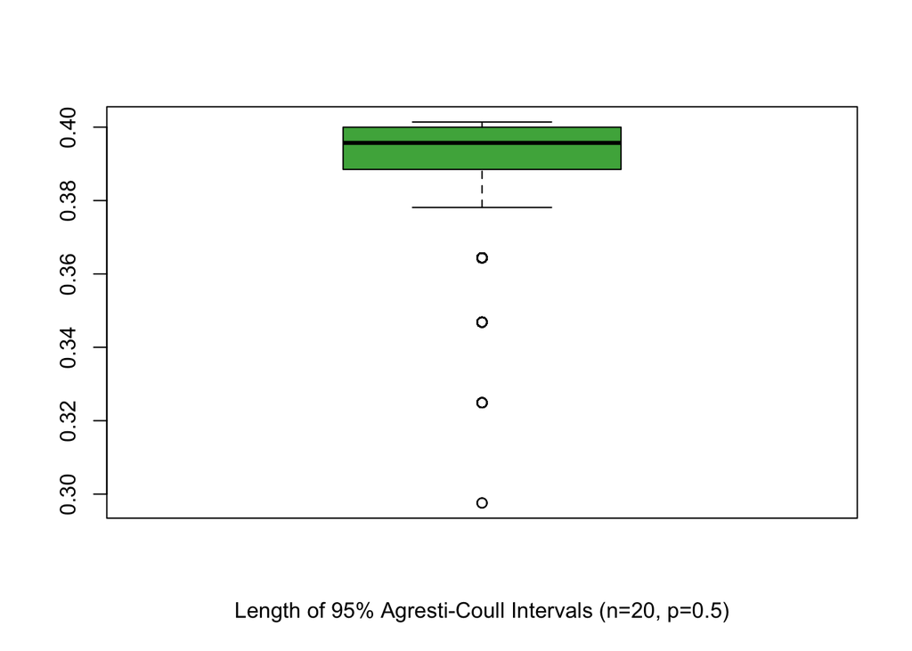

```r
set.seed(562)
p31 <- 0.5
n31 <- 20

agresti_lower1 <- c()
agresti_upper1 <- c()

for(i in 1:10000){
X_31 <- rbinom(prob=p31, size=n31, n=1)
intervals31 <- binom.confint(x=X_31, n=n31, conf.level=0.95, method='agresti-coull')

agresti_lower1[i] <- intervals31[1, 5]
agresti_upper1[i] <- intervals31[1, 6]
}

coverage_agresti1 <- sum(agresti_lower1 <= p31 & agresti_upper1 >=p31)/10000

length_agresti1 <- agresti_upper1 - agresti_lower1
boxplot(length_agresti1, col=cols[3], xlab='Length of 95% Agresti-Coull Intervals (n=20, p=0.5)')
```

```r
coverage_agresti1
```

```
## [1] 0.9616
```

```r
coverage_agresti_diff95_1 <- coverage_agresti1 - 0.95
coverage_agresti_diff95_1
```

```
## [1] 0.0116
```

```r
mean(length_agresti1)
```

```
## [1] 0.3941027
```

- The Agresti-Coull confidence interval with $p = 0.5, n = 20$ has a length of $0.3941$ and coverage level of $0.9616$. This exceeds the desired $95%$ confidence level by $0.0116$.

## $p = 0.5, n = 50$

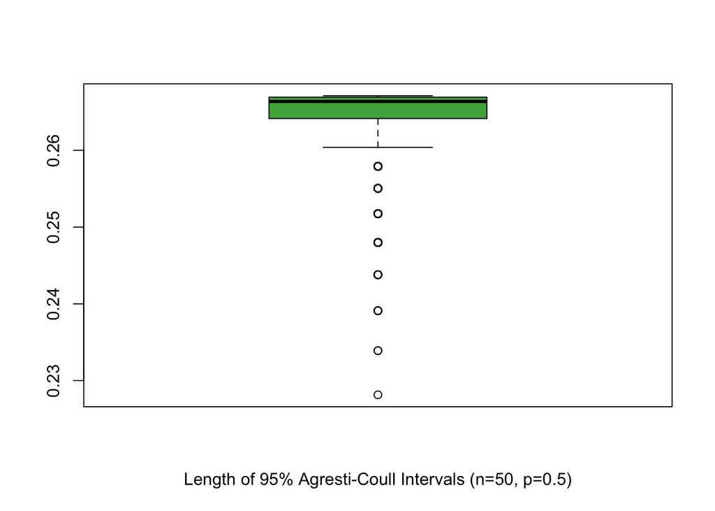

```r
set.seed(562)
p32 <- 0.5
n32 <- 50

agresti_lower2 <- c()
agresti_upper2 <- c()

for(i in 1:10000){
X_32 <- rbinom(prob=p32, size=n32, n=1)
intervals32 <- binom.confint(x=X_32, n=n32, conf.level=0.95, method='agresti-coull')

agresti_lower2[i] <- intervals32[1, 5]
agresti_upper2[i] <- intervals32[1, 6]
}

coverage_agresti2 <- sum(agresti_lower2 <= p32 & agresti_upper2 >=p32)/10000

length_agresti2 <- agresti_upper2 - agresti_lower2
boxplot(length_agresti2, col=cols[3], xlab='Length of 95% Agresti-Coull Intervals (n=50, p=0.5)')
```

```r
coverage_agresti2
```

```
## [1] 0.9359
```

```r
coverage_agresti_diff95_2 <- coverage_agresti2 - 0.95
coverage_agresti_diff95_2
```

```
## [1] -0.0141
```

```r
mean(length_agresti2)
```

```
## [1] 0.2647615
```

- The Agresti-Coull confidence interval with $p = 0.5, n = 50$ has a length of $0.2648$ and coverage level of $0.9359$. This falls short of the desired $95%$ confidence level by $0.0141$.

## $p = 0.7, n = 20$

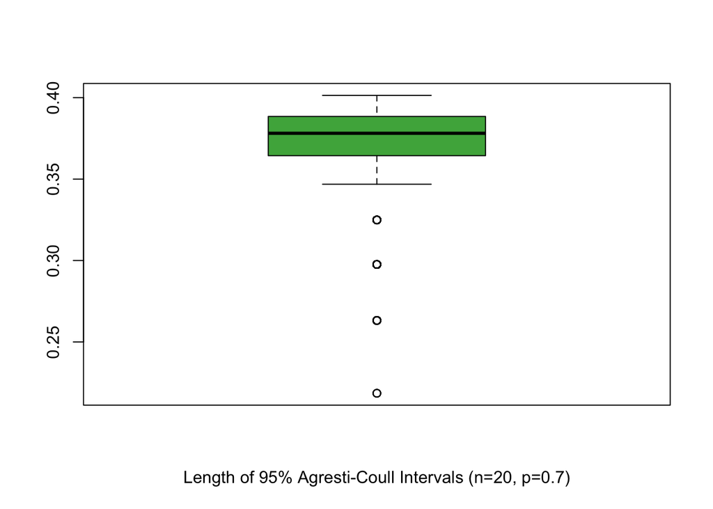

```r
set.seed(562)
p33 <- 0.7
n33 <- 20

agresti_lower3 <- c()
agresti_upper3 <- c()

for(i in 1:10000){
X_33 <- rbinom(prob=p33, size=n33, n=1)
intervals33 <- binom.confint(x=X_33, n=n33, conf.level=0.95, method='agresti-coull')

agresti_lower3[i] <- intervals33[1, 5]
agresti_upper3[i] <- intervals33[1, 6]
}

coverage_agresti3 <- sum(agresti_lower3 <= p33 & agresti_upper3 >=p33)/10000

length_agresti3 <- agresti_upper3 - agresti_lower3
boxplot(length_agresti3, col=cols[3], xlab='Length of 95% Agresti-Coull Intervals (n=20, p=0.7)')
```

```r
coverage_agresti3
```

```
## [1] 0.9769
```

```r
coverage_agresti_diff95_3 <- coverage_agresti3 - 0.95
coverage_agresti_diff95_3
```

```
## [1] 0.0269
```

```r
mean(length_agresti3)
```

```
## [1] 0.3707595
```

- The Agresti-Coull confidence interval with $p = 0.7, n = 20$ has a length of $0.3708$ and coverage level of $0.9769$. This exceeds the desired $95%$ confidence level by $0.0269$.

## $p = 0.7, n = 50$

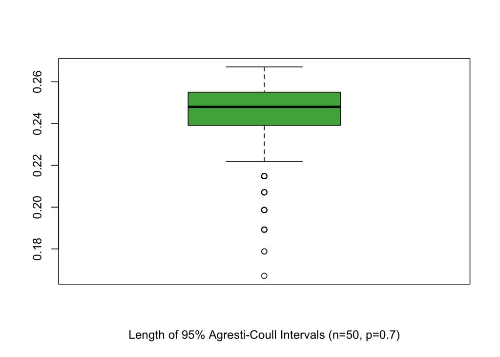

```r
set.seed(562)
p34 <- 0.7
n34 <- 50

agresti_lower4 <- c()
agresti_upper4 <- c()

for(i in 1:10000){
X_34 <- rbinom(prob=p34, size=n34, n=1)
intervals34 <- binom.confint(x=X_34, n=n34, conf.level=0.95, method='agresti-coull')

agresti_lower4[i] <- intervals34[1, 5]
agresti_upper4[i] <- intervals34[1, 6]
}

coverage_agresti4 <- sum(agresti_lower4 <= p34 & agresti_upper4 >=p34)/10000

length_agresti4 <- agresti_upper4 - agresti_lower4
boxplot(length_agresti4, col=cols[3], xlab='Length of 95% Agresti-Coull Intervals (n=50, p=0.7)')
```

```r
coverage_agresti4
```

```
## [1] 0.9587
```

```r
coverage_agresti_diff95_4 <- coverage_agresti4 - 0.95
coverage_agresti_diff95_4
```

```
## [1] 0.0087
```

```r
mean(length_agresti4)
```

```
## [1] 0.245532
```

- The Agresti-Coull confidence interval with $p = 0.7, n = 50$ has a length of $0.2455$ and coverage level of $0.9587$. This exceeds the desired $95%$ confidence level by $0.0087$.

## $p = 0.9, n = 20$

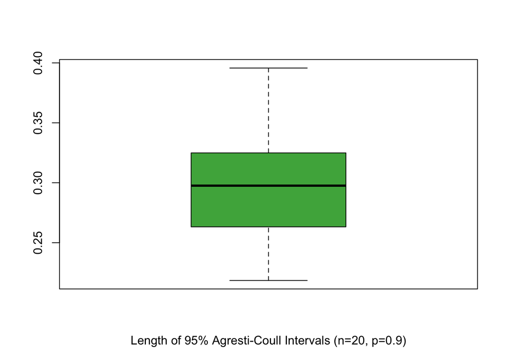

```r
set.seed(562)
p35 <- 0.9
n35 <- 20

agresti_lower5 <- c()
agresti_upper5 <- c()

for(i in 1:10000){
X_35 <- rbinom(prob=p35, size=n35, n=1)
intervals35 <- binom.confint(x=X_35, n=n35, conf.level=0.95, method='agresti-coull')

agresti_lower5[i] <- intervals35[1, 5]
agresti_upper5[i] <- intervals35[1, 6]
}

coverage_agresti5 <- sum(agresti_lower5 <= p35 & agresti_upper5 >=p35)/10000

length_agresti5 <- agresti_upper5 - agresti_lower5
boxplot(length_agresti5, col=cols[3], xlab='Length of 95% Agresti-Coull Intervals (n=20, p=0.9)')
```

```r
coverage_agresti5
```

```
## [1] 0.9553
```

```r
coverage_agresti_diff95_5 <- coverage_agresti5 - 0.95
coverage_agresti_diff95_5
```

```
## [1] 0.0053
```

```r
mean(length_agresti5)
```

```
## [1] 0.2911813
```

- The Agresti-Coull confidence interval with $p = 0.9, n = 20$ has a length of $0.2912$ and coverage level of $0.9553$. This exceeds the desired $95%$ confidence level by $0.0053$.

## $p = 0.9, n = 50$

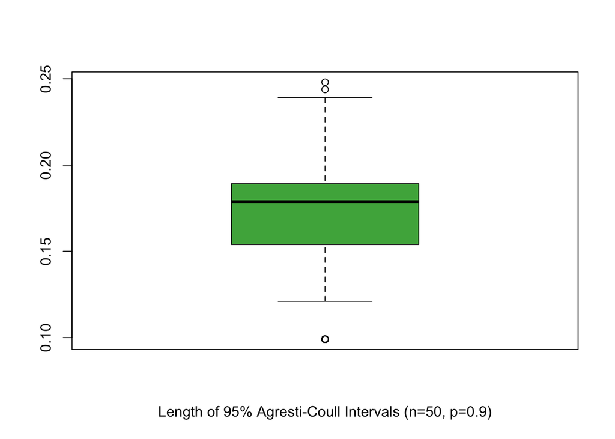

```r
set.seed(562)
p36 <- 0.9
n36 <- 50

agresti_lower6 <- c()
agresti_upper6 <- c()

for(i in 1:10000){
X_36 <- rbinom(prob=p36, size=n36, n=1)
intervals36 <- binom.confint(x=X_36, n=n36, conf.level=0.95, method='agresti-coull')

agresti_lower6[i] <- intervals36[1, 5]
agresti_upper6[i] <- intervals36[1, 6]
}

coverage_agresti6 <- sum(agresti_lower6 <= p36 & agresti_upper6 >=p36)/10000

length_agresti6 <- agresti_upper6 - agresti_lower6
boxplot(length_agresti6, col=cols[3], xlab='Length of 95% Agresti-Coull Intervals (n=50, p=0.9)')
```

```r
coverage_agresti6
```

```
## [1] 0.9713
```

```r
coverage_agresti_diff95_6 <- coverage_agresti6 - 0.95
coverage_agresti_diff95_6
```

```
## [1] 0.0213
```

```r
mean(length_agresti6)
```

```
## [1] 0.1759663
```

## Collected Data

[output not shown]

## Conclusions

### $p = 0.5, n = 20$

For this set of parameters, all three confidence intervals exceeded the desired coverage level of $95%$ by $0.0116$. The Wilson interval has the shortest length at $0.3926$ and the Wald interval has the largest length at $0.4268$. These results indicate that the Wilson confidence interval is the best performer for this particular set of parameters.

### $p = 0.5, n = 50$

For this set of parameters, all three confidence intervals fell short of the desired coverage level of $95%$ by $0.0141$. The Wilson interval has the shortest length at $0.2646$ and the Wald interval has the largest length at $0.2743$. These results indicate that the Wilson confidence interval is the best performer for this set of parameters.

### $p = 0.7, n = 20$

For this set of parameters, the Wald confidence interval fell short of the desired confidence level by $0.0012$. This is the closest interval to the desired confidence level. The Wilson confidence interval has the shortest length at $0.3643$ and the Wald has the largest length at $0.3888$. Since the Wald interval’s coverage is the closest to the desired confidence level, it can be considered the best performer for these parameters.

### $p = 0.9, n = 20$

For this set of parameters, the Wilson and Agresti-Coull intervals have coverage levels closest to the desired confidence level. They both exceed $95%$ by $0.0053$. The Wald interval has the shortest length at $0.2337$, the length of the Wilson interval is next at $0.2629$, followed by the Agresti-Coull interval at $0.2912$. With a strong balance of accurate coverage and short length, the Wilson interval is the best performing interval for these parameters.

### $p = 0.9, n = 50$

For this set of parameters, the Wilson and Agresti-Coull intervals have coverages levels that both exceed the desired confidence level of $95%$ by $0.0213$. The Wald interval has the shortest length at $0.1611$, followed by the Wilson at $0.1665$, and the Agresti-Coull at $0.1760$. Again, with a balance of accurate coverage and a short interval length, the Wilson interval is the best performer for these parameters.

### Overall

A brief analysis of the three confidence intervals for six sets of parameters led us to conclude that the Wilson interval is the best performer for five of the six sets of parameters and the Wald interval is the best performer for the final set of parameters.

In summation, the simulation results indicate that the Wilson confidence interval has the best overall performance combined between coverage levels near the desired value and short interval lengths. This would lead us to conclude that the Wilson interval is “better” than the Wald and Agresti-Coull intervals.